# Quantile Kriging with MOGP

Danny Williamson

The purpose of this vignette is to demonstrate the use of MOGP for quantile kriging and, in particular, how to use it for prediction. I also explain why sampling for quantile kriging prediction is necessary.

First, as ususal, I will set a pointer to `mogp_emulator` and source the right files from our R implementation `ExeterUQ_MOGP`. See [here](https://bayesexeter.github.io/ExeterUQ_MOGP/) for more information.

```r
mogp_dir <- "~/Dropbox/BayesExeter/mogp_emulator"
setwd("~/Dropbox/BayesExeter/ExeterUQ_MOGP")
source("~/Dropbox/BayesExeter/ExeterUQ_MOGP/BuildEmulator/BuildEmulator.R")
```

Load the data and some libraries for data manipulation.

```r
library(dplyr)
library(tidyr)
library(ggplot2)
library(readr)
data <- read_csv("data/Quantile_Emulation_MOGP/lads_by_day_cumulative_79.csv")
```

I extract the data names and then perform some manipulation so that there are no unusual characters in the variable strings.

```r
tnames <- names(data)[-c(1:5)]
tnames[1:5]
```

```
## [1] "Adur"         "Allerdale"    "Amber Valley" "Arun"
## [5] "Ashfield"
```

**Click here to see the string collapsing**

```r
for(i in 1:length(tnames)){
  tsplit <- strsplit(tnames[i],split=" ")[[1]]
  if(length(tsplit)>1)
    tnames[i] <- paste(tsplit,collapse = "")
}
for(i in 1:length(tnames)){
  tsplit <- strsplit(tnames[i],split="-")[[1]]
  if(length(tsplit)>1)
    tnames[i] <- paste(tsplit,collapse = "")
}
for(i in 1:length(tnames)){
  tsplit <- strsplit(tnames[i],split=",")[[1]]
  if(length(tsplit)>1)
    tnames[i] <- paste(tsplit,collapse = "")
}
for(i in 1:length(tnames)){
  tsplit <- strsplit(tnames[i],split="'")[[1]]
  if(length(tsplit)>1)
    tnames[i] <- paste(tsplit,collapse = "")
}
```

Now let’s divide the data into inputs and outputs

```r
data_frame <- as.matrix(data)
X <- data_frame[,1:5]
y <- data_frame[,7:ncol(data_frame)]
```

This step is controversial and square roots the data to ensure all output is positive. There are other approaches here that might be better. A major issue is that we do have $0$ infections in a lot of spots, and so we might need a model that uses that idea. This vignette is focussed on getting a quantile emulator working with mogp.

```r
y <- sqrt(y)
```

Let’s split into training and testing data

```r
X_valid <- X[126:200,]
y_valid <- y[126:200,]
X <- X[1:125,]
y <- y[1:125,]
```

**The following function (`QK_data(X,y)`) extracts the quantiles for every output, it’s a bit long so click here to see it (it’s a slight adaptation of Evan’s code).**

```r
QK_data <- function(X, y){
  full_output <- as.matrix(y)
  output_dim <- ncol(full_output)
  quantile_dfs <- list()
  y1 <- full_output[,1]
  quantile_df <- data.frame(X = X, y1 = y1)
  quantile_df <-  quantile_df %>% group_by_at(vars(names(quantile_df)[1:(length(X[1,]))])) %>% summarise("0.025" = quantile(y1, 0.025), "0.25" = quantile(y1, 0.25), "0.5" = quantile(y1, 0.5), "0.75" = quantile(y1, 0.75), "0.975" = quantile(y1, 0.975))
  final_df <-  quantile_df %>% gather(Quantile, y1, "0.025":"0.975")
  names(final_df)[ncol(final_df)] <- tnames[1]
  for(i in 2:ncol(full_output)){
    y1 <- full_output[,i]
    quantile_df <- data.frame(X = X, y1 = y1)
    quantile_df <-  quantile_df %>% group_by_at(vars(names(quantile_df)[1:(length(X[1,]))])) %>% summarise("0.025" = quantile(y1, 0.025), "0.25" = quantile(y1, 0.25), "0.5" = quantile(y1, 0.5), "0.75" = quantile(y1, 0.75), "0.975" = quantile(y1, 0.975))
    quantile_df <- quantile_df %>% gather(Quantile, y1, "0.025":"0.975")
    final_df <- merge(final_df, quantile_df)
    names(final_df)[ncol(final_df)] <- tnames[i]
  }
final_df
}
```

Run the function to obtain the quantile data and ensure the format is right for `ExeterUQ_MOGP`.

```r
final_df <- QK_data(X,y)
Noise <- rnorm(nrow(final_df),0,0.4)
tData <- cbind(final_df[,1:6],Noise,final_df[,7:ncol(final_df)])
tData$Quantile <- as.numeric(tData$Quantile)
```

Now we fit all of the emulators. This function takes approximately 2 minutes on my laptop. Currently this will be unavailable for windows users due to the hyperthreading, but a fix is being worked on for this.

```r
MetaEmulatorsAll <- BuildNewEmulators(tData, HowManyEmulators = ncol(tData)-7, meanFun = "linear", kernel = "Matern52",additionalVariables = names(tData)[1:6])
```

The following function is long but is kind of the point of the vignette, so I will show it. The idea is to use the parallel predictive speed to draw quantile samples for the whole UK at the same time. Before we get into it, a little bit of theory will explain why we need this sampling step.

Let the output of Metawards for a given input vector $x$ be $Y(x)$. Dropping $x$ for notational convenience (just imagine it’s there throughout), the pdf of $Y$ is $f(y)$ and is unknown. Let $q$ be a quanitle of $Y$ then our emulator is effectively
$$Y\mid q \sim \mathrm{GP}(m(q), V(q))$$
and so we have $f(y\mid q)$ and more importantly we can sample from it. The standard marginalisation trick,
$$f(y) = \int_{-\infty}^{\infty}f(y,q)dq = \int_{-\infty}^{\infty}f_Y(y\mid q)f_Q(q)dq,$$
so that, we can integrate $q$ using Monte Carlo by sampling from $f_Q(q)$.

**Click here for details if this is unclear.**

If we sample from $f(y,q)$ and only keep the $y$ samples, we have a valid sample from $f(y)$. It is this trick that makes much of MCMC work. Here, if we can sample from $f_Q(q)$, then we can plug the $q$ samples into our GP, draw a sample from that ($f(y\mid q)$) and the Metawards realisation alone is a sample from $f(y)$.

Carrying on, the actual values of the quantiles are values of the cdf $F(y)$! So $f_Q(q) = 1$ (we learn this in my Bayesian course, see the clickable below), and we can sample $q$ from $\mathrm{Unif}(0,1)$.

**Why does the cdf have a uniform distribution?**

It’s a calculation every 3rd year Bayesian knows by heart! Let $W = F(Y)$, then the CDF of random quantity $W$ is
$$\begin{align*}
P(W\leq w) &= P(F(X)\leq w)\\
&= P(F^{-1}F(X)\leq F^{-1}(w)) \\
&= P(X\leq F^{-1}(w)) = FF^{-1}(w) = w.
\end{align*}$$
So $f(w) = \frac{dF}{dw} = 1$ and $W \sim \mathrm{Unif}(0,1).$

So to obtain samples from the distribution of $Y$ we need to sample the quantiles and then sample the conditional GP. This function uses to parallel optimisation features of MOGP to obtain the samples efficiently for `Design`, a given prediction design and use those to obtain desired quantiles.

```r
QuantilePrediction <- function(Design, mogp, numSamples=1000,
                               Quantiles = c(0.05,0.25,0.5,0.75,0.95)){
  #'@param Design The design matrix where predictions are required.
  #'@param mogp An mogp emulator
  #'@param numSamples how many quantile samples are used for each Design.
  #'@param Quantiles Which quantiles of the samples to return.
  N <- dim(Design)[1]
  tsamples <- runif(numSamples*N) #Quantile samples
  mogpDesign <- cbind(repmat(Design, numSamples,1),tsamples) #Expanding design to do all in one parallel prediction
  names(mogpDesign)[dim(mogpDesign)[2]] <- "Quantile"
  tpreds <- mogp$mogp$predict(mogpDesign, deriv=FALSE) #Emulator predictions in 1 shot. Coming GPU features will make these even more efficient.
  Draws <- sapply(1:mogp$mogp$n_emulators, function(k) rnorm(length(tsamples), mean = tpreds$mean[k,], sd= sqrt(tpreds$unc[k,]))) #For each GP mean and variance, draw a single realisation $Y$.
  #Trick now we have fast samples, is combining correctly and remembering there is a multi-wards issue!
  QuantNames <- names(quantile(runif(100),probs=Quantiles))
  Output <- array(NA, dim=c(N,length(Quantiles),mogp$mogp$n_emulators),dimnames=list(NULL,QuantNames,tnames[1:mogp$mogp$n_emulators]))#Assuming building the first few emulators otherwise ward names will be wrong.
  IndexSequence <- seq(from=0, by=numSamples, length.out = N)
  for(i in 1:N){
    Output[i,,] <- apply(Draws[IndexSequence+i,],2,quantile, probs=Quantiles)
  }
  Output #Note there may be a tidy efficient way to do this combination
}
```

Note that the function produces a 3D array with dimensions $N\times Q \times M$ where $N$ is the number of new prediction locations, $Q$ is the number of quantiles returned and $M$ is the number of outputs or wards.

Calling the function to predict the validation set

```r
APred <- QuantilePrediction(X_valid, mogp=MetaEmulatorsAll, numSamples = 1000)
```

We can once again produce predictions for the validation set. I will do this for the local authorities in the South West.

```r
NewNames <- c("BathandNorthEastSomerset", "BristolCityof", "Cornwall", "EastDevon", "EastDorset", "Exeter", "IslesofScilly", "MidDevon", "NorthDevon", "Plymouth", "SouthHams", "SouthSomerset", "Torbay", "WestDevon", "WestDorset", "WestSomerset")
SouthWestPred <- APred[,,which(dimnames(APred)[[3]] %in% NewNames)]
SouthWestValid <- y_valid[,which(dimnames(APred)[[3]] %in% NewNames)]
SouthWestPred <- SouthWestPred^2 #Undoing the sqrt
SouthWestValid <- SouthWestValid^2 #Undoing the sqrt
```

A tidy solution would mean this part of the code would not be so clunky. Here is a plotting function to look at the emulator performance for any input and local authority:

```r
PlotLocalAuthority <- function(which.la=1, which.x=1){
  Valid <- SouthWestValid[,which.la] >= SouthWestPred[,1,which.la] & SouthWestValid[,which.la] <=   SouthWestPred[,5,which.la]
  ggplot()+
    geom_point(aes(x=X_valid[,which.x], y= SouthWestPred[,3,which.la]))+
    geom_errorbar(aes(x=X_valid[,which.x], ymin = SouthWestPred[,1,which.la],ymax=SouthWestPred[,5,which.la]))+
    geom_point(aes(x=X_valid[Valid,which.x], y = SouthWestValid[Valid,which.la]), colour = "blue")+
    geom_point(aes(x=X_valid[!Valid,which.x], y = SouthWestValid[!Valid,which.la]), colour = "red")+
    ylab("Infections")+
    xlab(names(tData)[which.x])+
    ggtitle(NewNames[which.la])
}
```

Now plotting the validation sets across the Southwest:

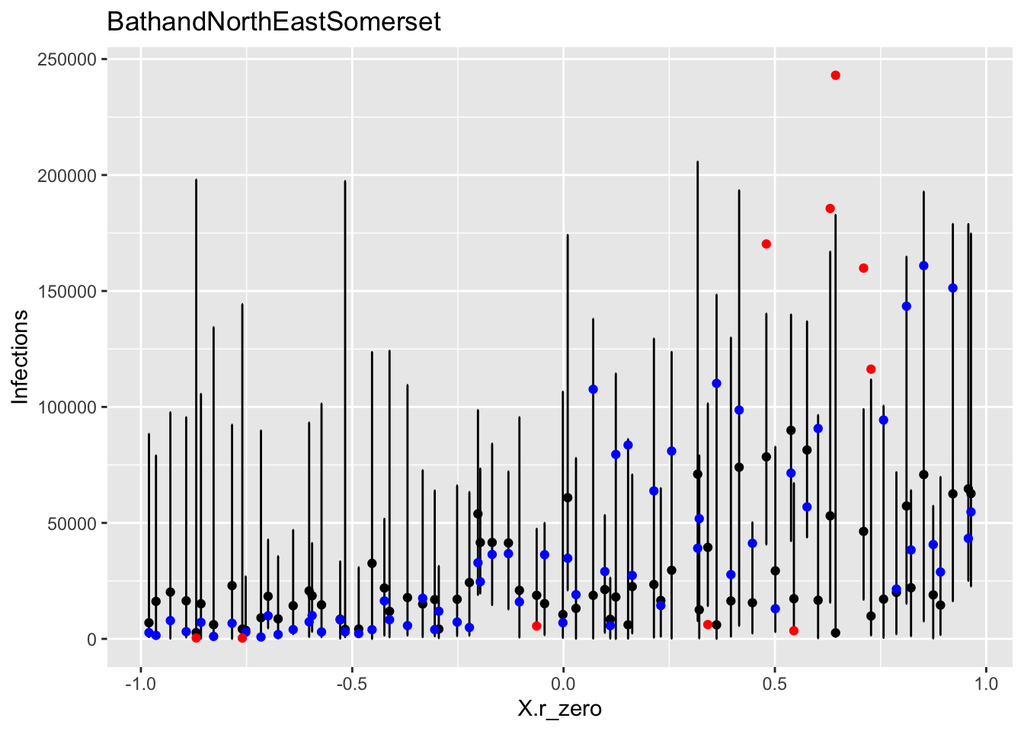

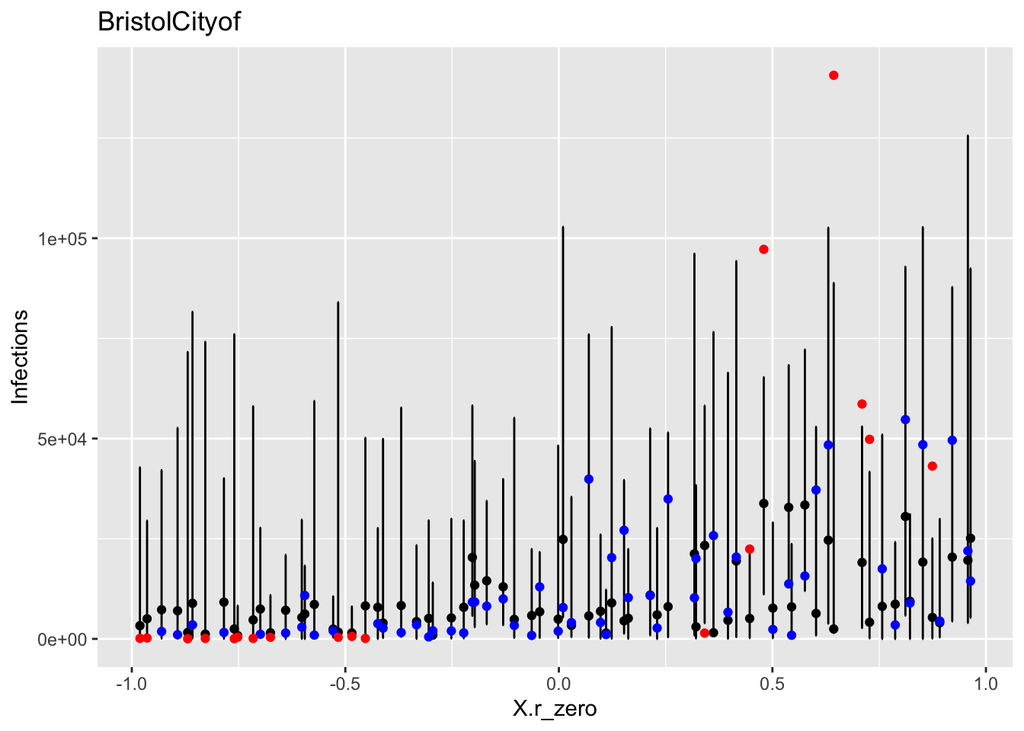

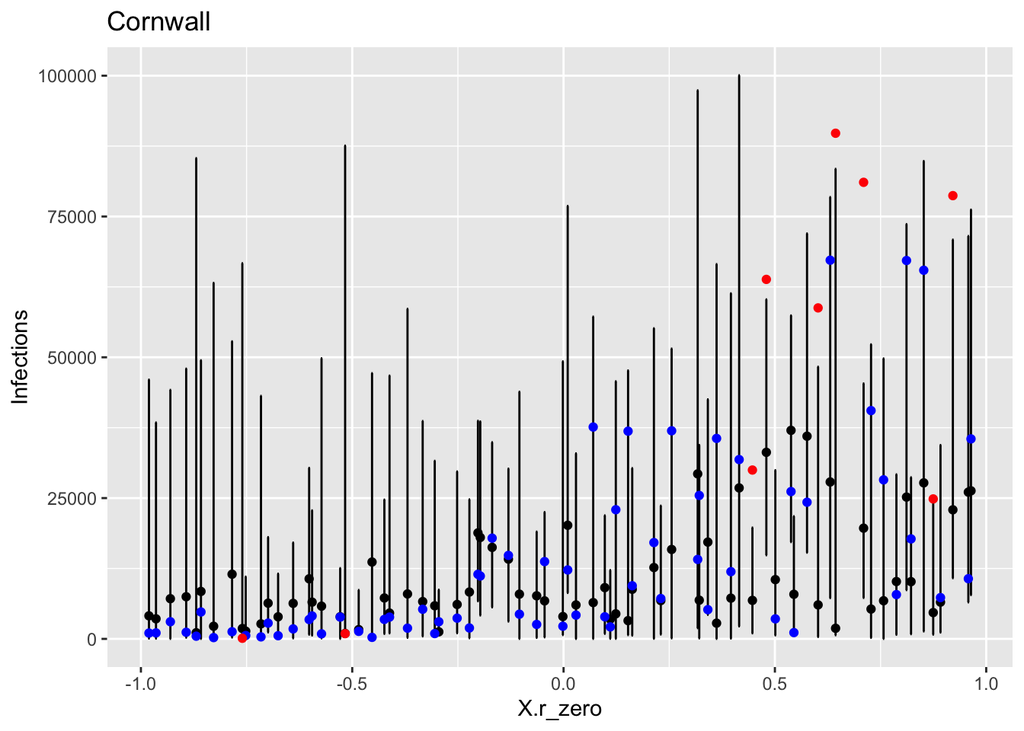

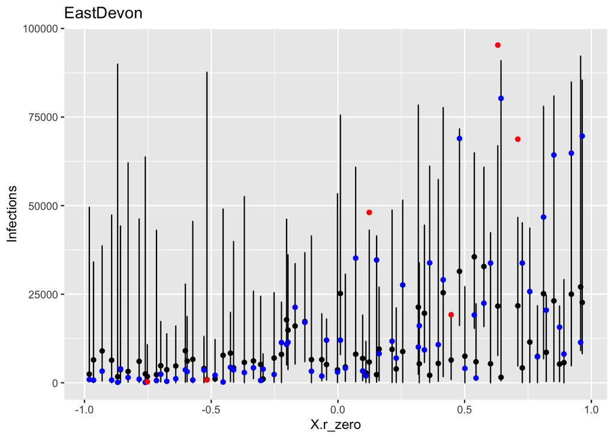

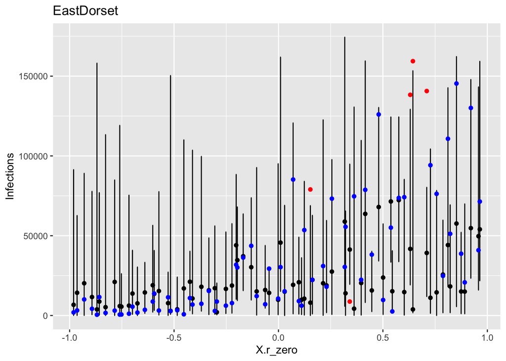

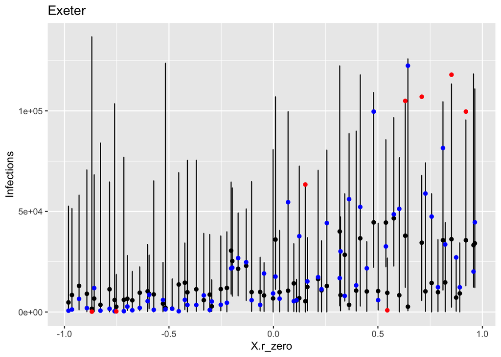

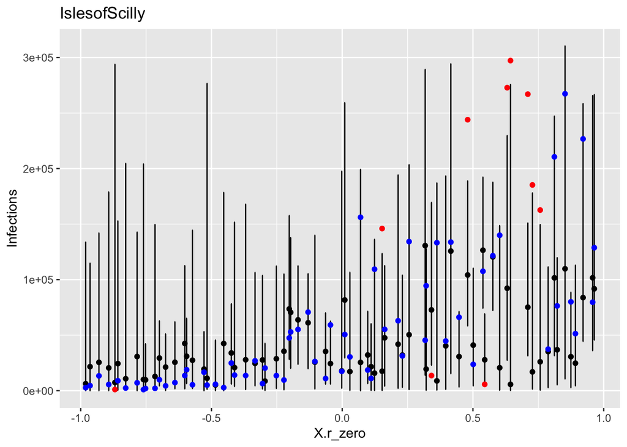

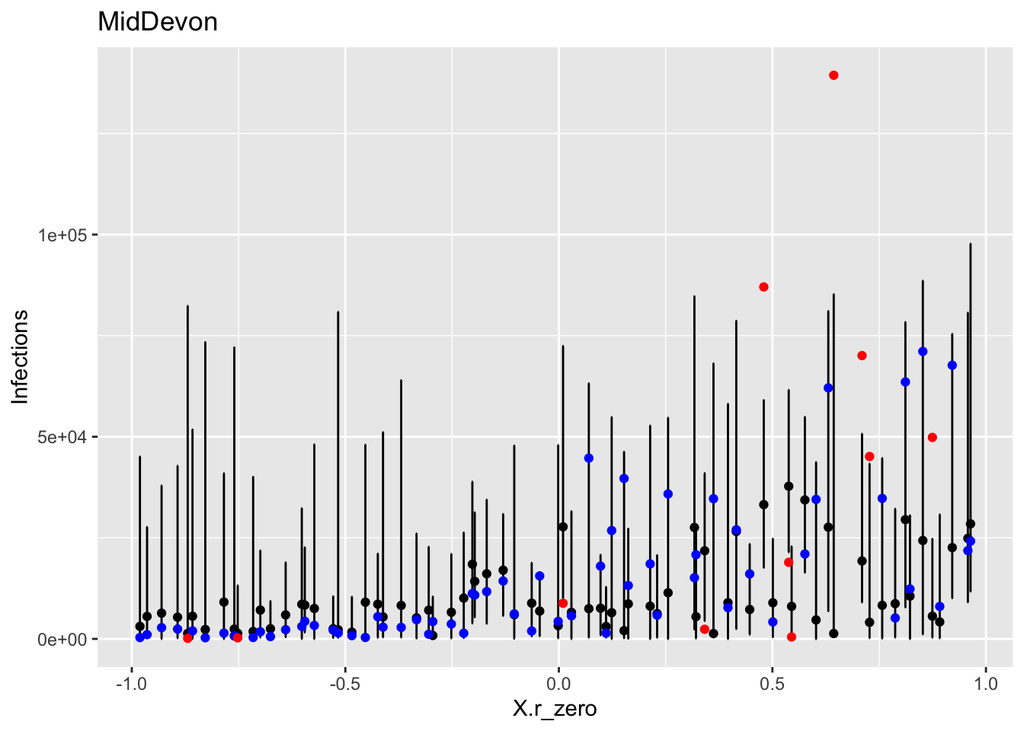

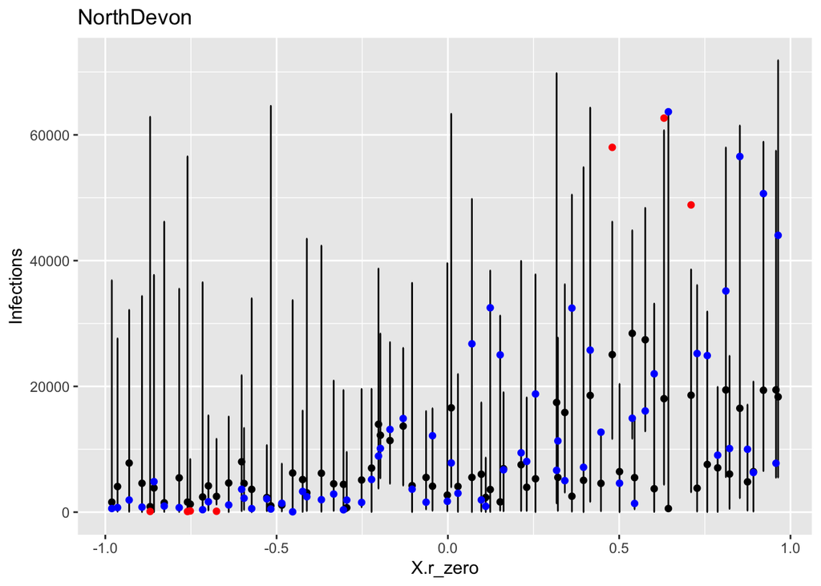

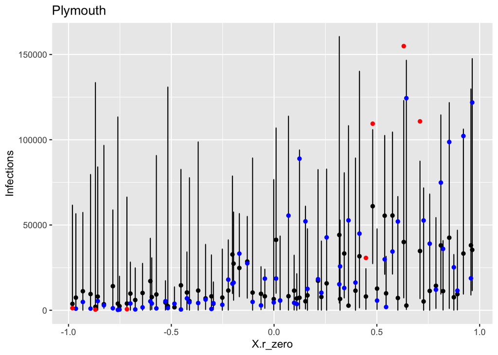

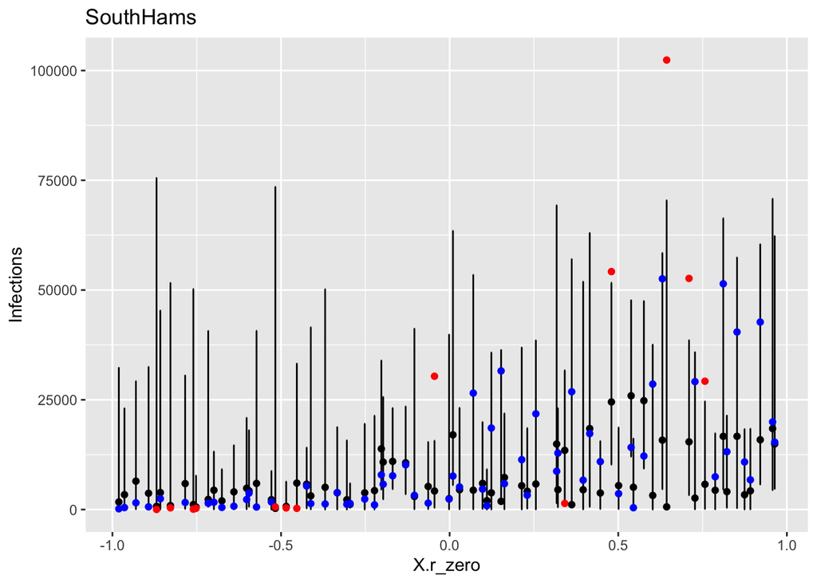

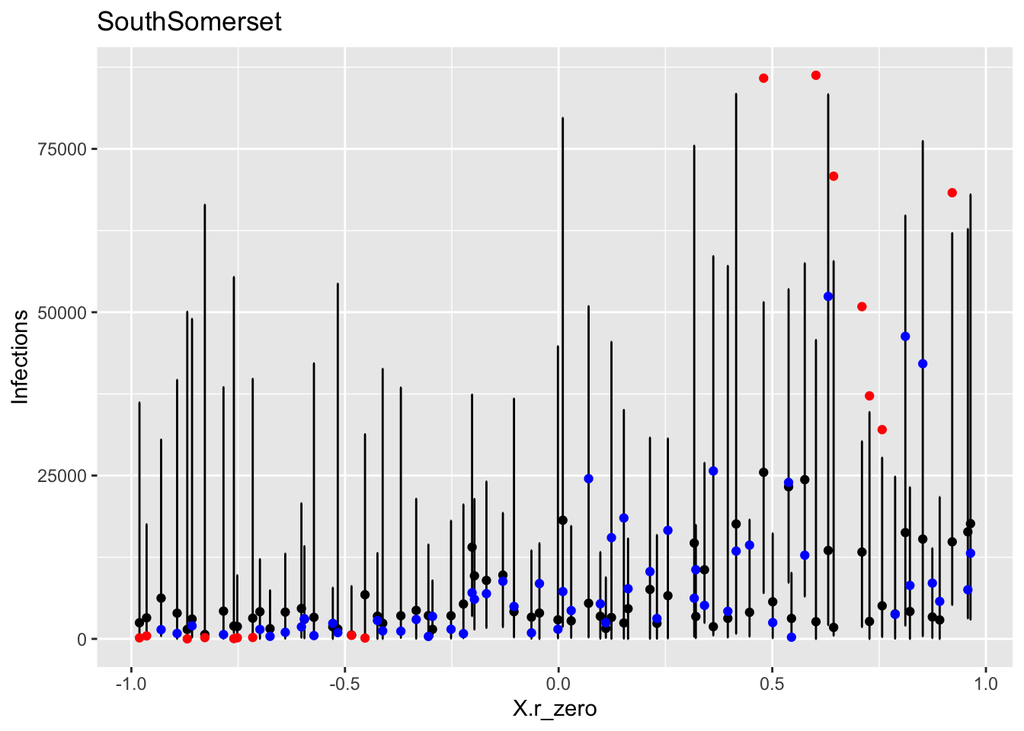

[4 more figures not shown]

```r
for(i in 1:length(NewNames)){
  print(PlotLocalAuthority(i,3))
}
```

Of course the performance here is questionable as the data only has 5 repeats per run. We should therefore not expect to have actually emulated the quantiles. More repeats will unlock whether this analysis is feasible.

## Where next?

- Run more repeats and repeat the analysis.
- A tidy solution to storing the prediction quantiles for easy plotting. Can anyone help?
- Revisit the square root idea.
- Calibration (when the new ensembles arrive.)